# q2

Question 2.

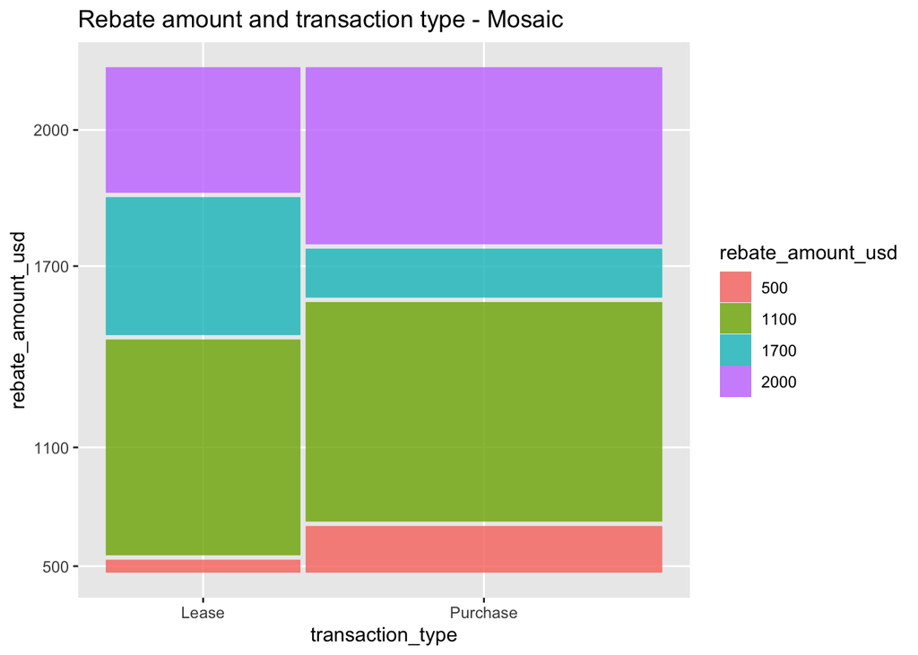

```r
library(ggplot2)
library(ggmosaic)
library(ggthemes)

# Loading car data
data <- read.csv("https://data.ny.gov/resource/thd2-fu8y.csv")
# Converting to factor
data$rebate_amount_usd <- as.factor(data$rebate_amount_usd)
data$rebate_cat <- as.factor(data$rebate_amount_usd)


# Creating mosaic plot
ggplot(data = data) +
  geom_mosaic(aes(x = product( rebate_amount_usd, transaction_type),
                  fill=rebate_amount_usd))+scale_colour_colorblind() + labs(title='Rebate amount and transaction type - Mosaic')
```

This graph has also been made with the color blind-friendly scale and the screenshot is attached.

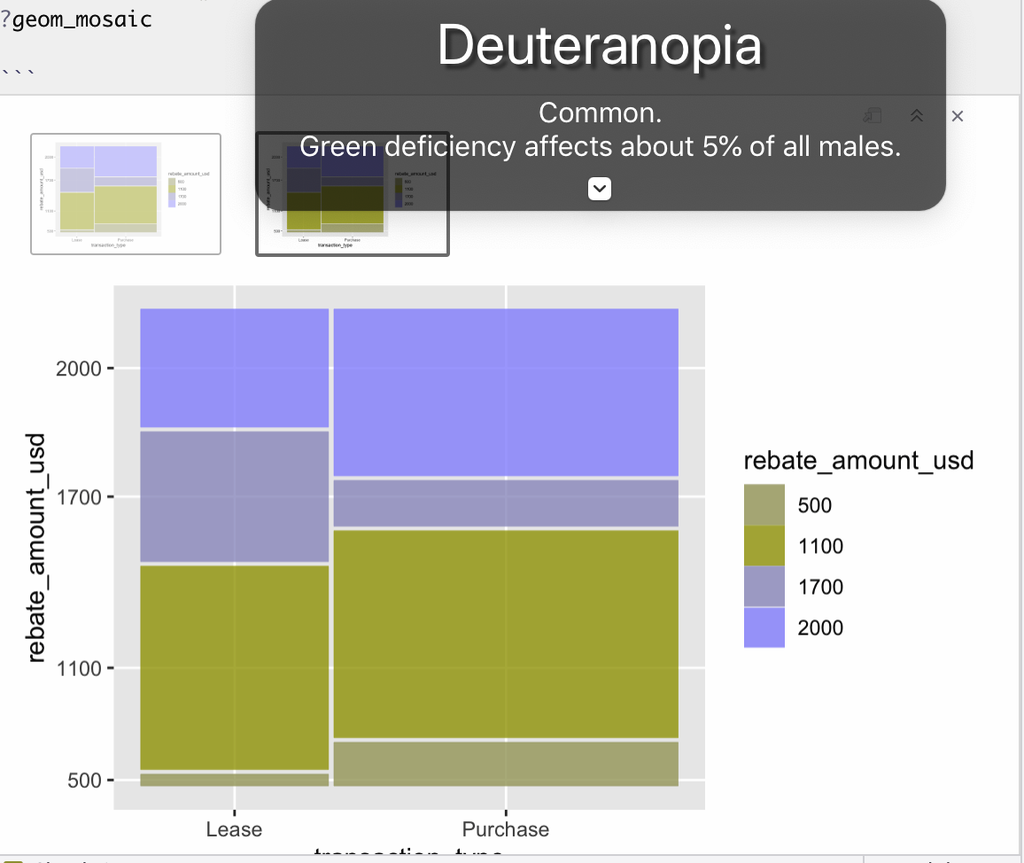

color-blind-friendly

There seems to be an association between the transaction type and the rebate amount. ‘Purchase’ transaction types seem to have higher occurrences of 500 and 2000 as rebate amounts. ‘Lease’ transaction type has higher occurrence of 1700 as the rebate amount.

```r
chisq.test(data$transaction_type, data$rebate_amount_usd)
```

```
##
##  Pearson's Chi-squared test
##
## data:  data$transaction_type and data$rebate_amount_usd
## X-squared = 69.463, df = 3, p-value = 5.562e-15
```

According to the results of the chi-square test, we can see that the p value is around e^-15. This means that the result is significant and there is an association between transaction type and rebate amount.

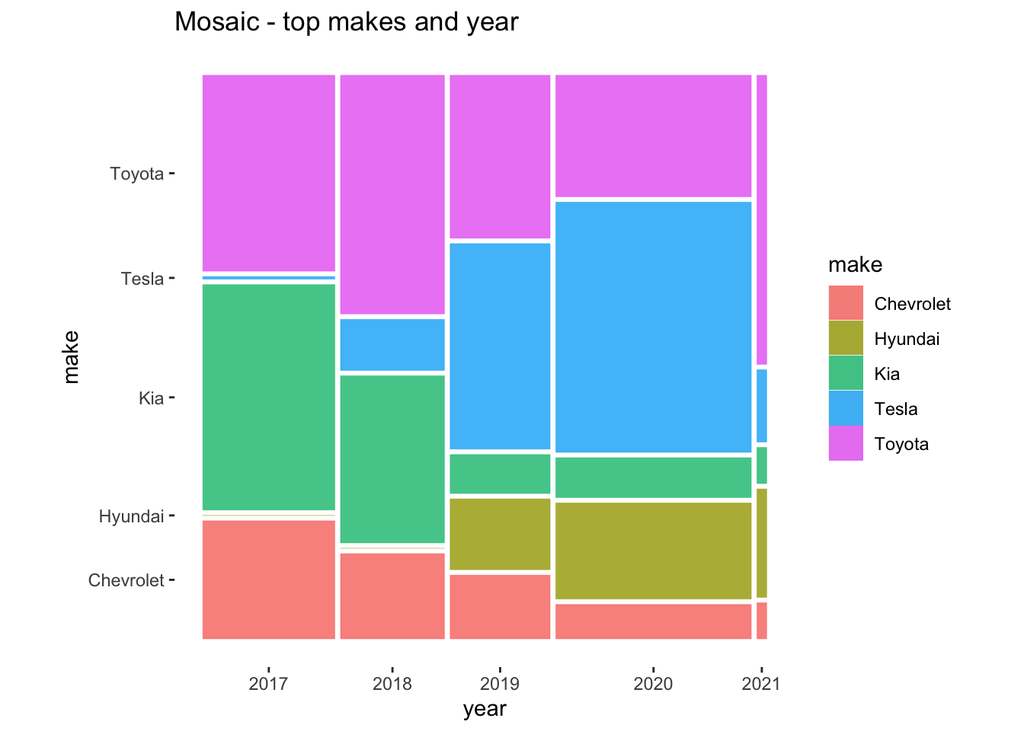

```r
# Extracting the top 5 makes
t <- sort(table(data$make), decreasing = TRUE)
t <- factor(data.frame(t[1:5])$Var1)
data_top <- data[data$make %in% t,]

# Converting to date format to extract year
data_top$year <- format(as.Date(data_top$submitted_date), '%Y')

# Creating mosaic plot
# With color blind scale
ggplot(data = data_top) +
  geom_mosaic(aes(x = product(make, year),
                  fill=make))  + theme_mosaic() + labs(title='Mosaic - top makes and year')
```

```r
# any change?
```

There seems to be a clear relation between the year and the make of the cars. In the year 2017, Tesla had a very small proportion of cars, whereas by 2020, it was the largest. The opposite is true for Kia, who had a much larger number in 2017 compared to 2020. Hyundai until 2019 did not seem to have any data pertaining to rebates.

All this shows that the number of rebates for a brand is clearly dependent on the year.

```r
library(vcd)
```

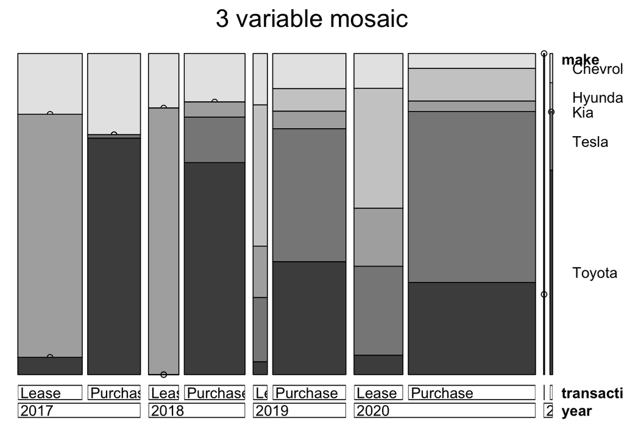

```r
# Using doubledecker for 3 variables
vcd::doubledecker(make ~ year + transaction_type, data=data_top, main='3 variable mosaic')
```

We see from this data that rebates for leasing and purchasing activities of these top 5 makes, were lower in 2018 and 2019 in comparison to 2020 and 2017.

Through all 5 years, the Toyota make is much more popular for purchase rebates, rather than leasing rebates. The Tesla make had negligible number of rebates for leasing until 2019, when there was a sudden increase.

Through 2017 and 2018, the Kia make was very popular for leasing rebates, but not for purchasing. Starting in 2019, it’s share of the rebates has been reducing.

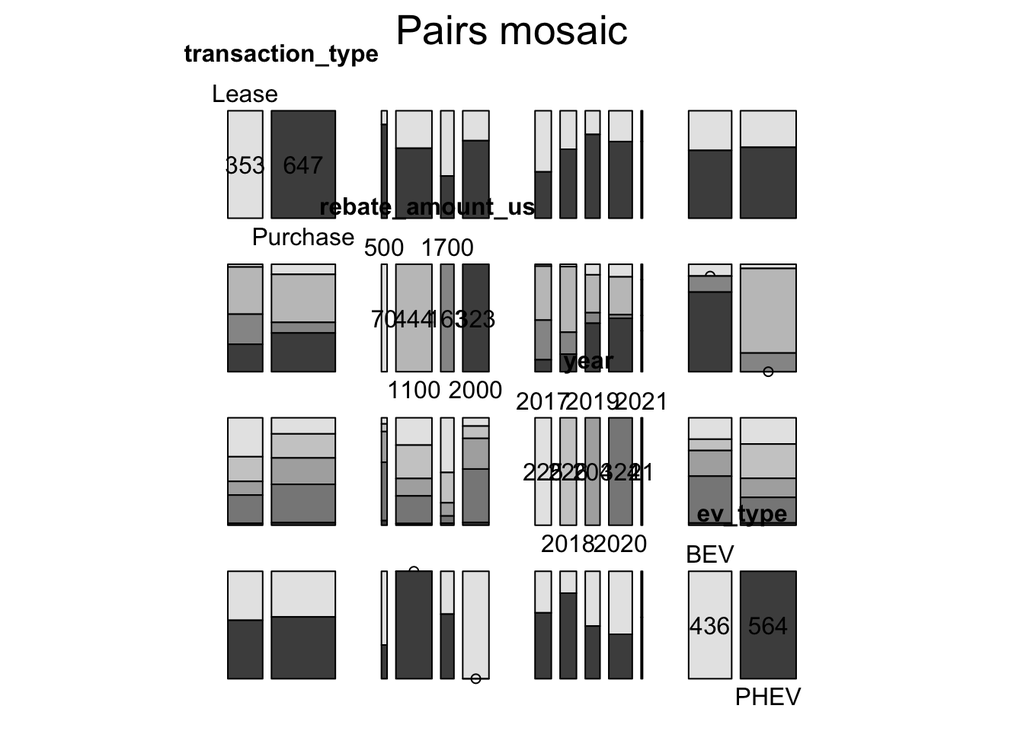

```r
# Creating copy of data
data_copy <- data

# Extracting year information
data_copy$year <- format(as.Date(data_copy$submitted_date), '%Y')

# Creating strcutable, helpful for frequencies
hec = structable(ev_type ~ transaction_type + rebate_amount_usd + year, data = data_copy)

# Creating pairs plot -mosaic
pairs(hec,
      highlighting = 2,
      diag_panel_args = list(fill = grey.colors),
      main='Pairs mosaic')
```

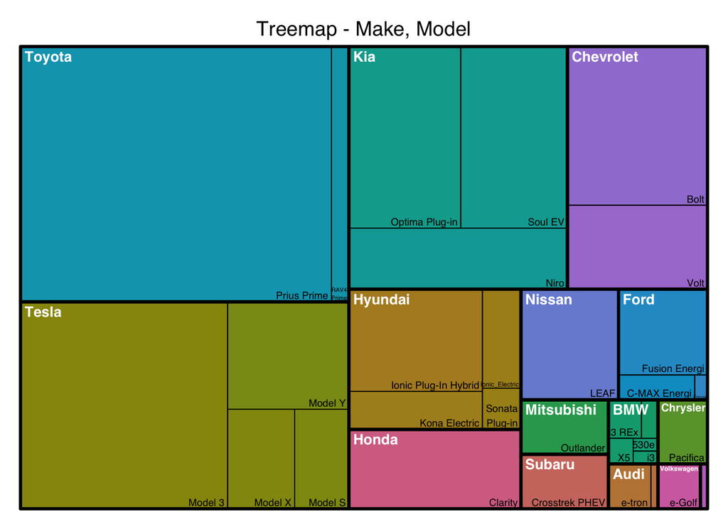

```r
library(ggthemes)
library(graphics)
library(treemap)
datat <- data.frame(data)
datat$new <-1
# Creating treemap
treemap(datat,
        index=c("make","model"),
        vSize="new",
        type="index",
        fontsize.labels=c(10,7),
        fontcolor.labels=c("white","black"),
        fontface.labels=c(2,1),
        bg.labels=c("transparent"),
        align.labels=list(
          c("left", "top"),
          c("right", "bottom")
          ),
        overlap.labels=0.5,
        inflate.labels=F,
        title='Treemap - Make, Model') + scale_color_colorblind()
```